# Data Modeling

## Method

```r
library(tidyverse)
library(caret)
library(skimr)
library(RANN)
library(rpart)
library(rpart.plot)
library(randomForest)
library(gbm)
library(elasticnet)

app_store_df <- read.csv("../Data/AppleStore.csv")
app_store_df <- mutate(app_store_df, size_mb = size_bytes/1000000)
app_store_df <- mutate(app_store_df, is_free = price == 0)
app_store_df <- mutate(app_store_df, user_rating_string = as.character(user_rating))
app_store_df <- na.omit(app_store_df)
sapply(app_store_df, class)
```

```
                 X                 id         track_name
         "integer"          "integer"           "factor"
        size_bytes           currency              price
         "numeric"           "factor"          "numeric"
  rating_count_tot   rating_count_ver        user_rating
         "integer"          "integer"          "numeric"
   user_rating_ver                ver        cont_rating
         "numeric"           "factor"           "factor"
       prime_genre    sup_devices.num    ipadSc_urls.num
          "factor"          "integer"          "integer"
          lang.num            vpp_lic            size_mb
         "integer"          "integer"          "numeric"
           is_free user_rating_string
         "logical"        "character"
```

```r
index <- createDataPartition(app_store_df$rating_count_tot, p=0.75, list=FALSE)
trainSet <- app_store_df[ index,]
testSet <- app_store_df[-index,]
str(trainSet)
```

```
'data.frame':   5400 obs. of  20 variables:
 $ X                 : int  1 2 4 6 7 8 9 10 11 12 ...
 $ id                : int  281656475 281796108 282614216 283619399 283646709 284035177 284666222 284736660 284791396 284815117 ...
 $ track_name        : Factor w/ 7195 levels "-The ç©´é\200šã\201—3D- å\220›ã\201®è¨\230æ†¶åŠ›xå\217\215å°„ç¥žçµŒã‚’å•\217ã\201†! ï½žMr.CURVEã\201‹ã‚‰ã\201®æŒ‘æ\210¦çŠ¶ ï½ž",..: 4747 2617 2479 5572 4820 4766 4823 4357 5829 5521 ...
 $ size_bytes        : num  1.01e+08 1.59e+08 1.29e+08 1.05e+07 2.28e+08 ...
 $ currency          : Factor w/ 1 level "USD": 1 1 1 1 1 1 1 1 1 1 ...
 $ price             : num  3.99 0 0 0.99 0 0 9.99 3.99 4.99 7.99 ...
 $ rating_count_tot  : int  21292 161065 262241 8253 119487 1126879 1117 7885 76720 105776 ...
 $ rating_count_ver  : int  26 26 649 5516 879 3594 4 40 4017 166 ...
 $ user_rating       : num  4 4 4 4 4 4 4.5 4 4.5 3.5 ...
 $ user_rating_ver   : num  4.5 3.5 4.5 4 4.5 4.5 5 4 4.5 2.5 ...
 $ ver               : Factor w/ 1590 levels "0.0.15","0.13",..: 1380 1515 1237 455 1360 1523 1009 1068 1097 1248 ...
 $ cont_rating       : Factor w/ 4 levels "12+","17+","4+",..: 3 3 1 3 3 1 3 3 3 3 ...
 $ prime_genre       : Factor w/ 23 levels "Book","Business",..: 8 16 18 8 6 12 22 8 8 8 ...
 $ sup_devices.num   : int  38 37 37 47 37 37 37 38 38 37 ...
 $ ipadSc_urls.num   : int  5 5 5 5 0 4 5 0 4 0 ...
 $ lang.num          : int  10 23 9 1 19 1 1 10 11 6 ...
 $ vpp_lic           : int  1 1 1 1 1 1 1 1 1 1 ...
 $ size_mb           : num  100.8 158.6 128.5 10.5 227.8 ...
 $ is_free           : logi  FALSE TRUE TRUE FALSE TRUE TRUE ...
 $ user_rating_string: chr  "4" "4" "4" "4" ...
```

```r
control <- rfeControl(functions = rfFuncs,
                   method = "repeatedcv",
                   repeats = 3,
                   verbose = FALSE)
outcomeName<-'rating_count_tot'

predictors<-names(trainSet)[!names(trainSet) %in% outcomeName]

predictors<-c("price", "prime_genre", "cont_rating", "size_mb", "is_free")
```

```r
fitControl <- trainControl(
  method = "repeatedcv",
  number = 5,
  repeats = 5,
  allowParallel = TRUE,
  )

grid <- expand.grid(n.trees=c(10,20,50,100,500,1000),shrinkage=c(0.01,0.05,0.1,0.5),n.minobsinnode = c(3,5,10),interaction.depth=c(1,5,10))

model_gbm <- readRDS("../Models/final_model.rds")
model_ridge <- readRDS("../Models/ridge_model.rds")
```

```r
predictions_ridge<-predict.train(object=model_ridge,testSet[,predictors],type="raw")
predictions_gdm<-predict.train(object=model_gbm,testSet[,predictors],type="raw")
summary(predictions_ridge)
```

```
   Min. 1st Qu.  Median    Mean 3rd Qu.    Max.
 -12125    3368   13433   12350   19228   53685
```

```r
summary(predictions_gdm)
```

```
   Min. 1st Qu.  Median    Mean 3rd Qu.    Max.
   9401    9785   10766   13199   15621  113276
```

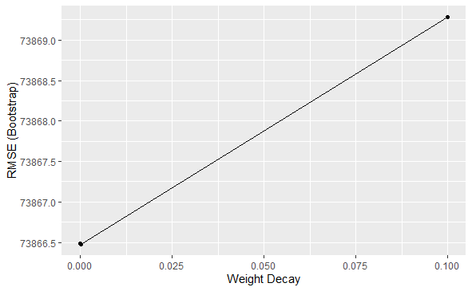

```r
ggplot(model_ridge)
```

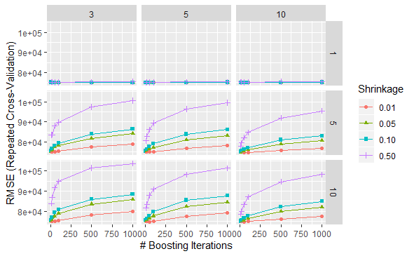

```r
ggplot(model_gbm)
```

## Results

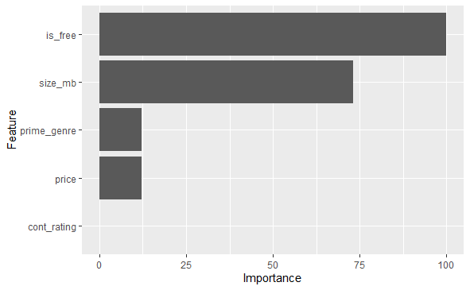

```r
ggplot(varImp(model_ridge))
```

According to the Ridge Regression variable importance plot, the most important factors in determining an app’s success (total rating count) is if the app was free or not. Second is the app’s total size in megabytes. The actual price of the app has a slight affect of the overall rating count if the app is paid. The prime genre also has slight importance. However, the content rating of the app is not important at all in determining the overall rating count.

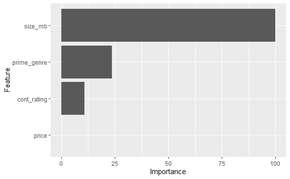

```r
ggplot(varImp(model_gbm))
```

The GBM variable importance plot does not contain if the app is free or not, but does contain the rest of the predictors. The most important variable in this is the app’s total download size. The prime genre of the app has slight importance as as well. Where this differs from the Ridge Regression model is the importance of content rating and price with both variables having swapped postiion from the Ridge Regression model.s